# matrix_factorisation

### Imports

```python
import pandas as pd
import numpy as np
import random
import math

import matplotlib.pyplot as plt
from matplotlib.pyplot import figure

import seaborn as sns
sns.set_style("whitegrid", {"grid.linestyle": ":"})
# sns.set_style("darkgrid", {"grid.linestyle": ":"})
sns.set_context("paper", rc={"font.size":11.5,"axes.titlesize":13,"axes.labelsize":11.5})

sns.set(rc={"figure.dpi":300, 'savefig.dpi':300})
sns.set_context('notebook')
sns.set_style("ticks")

import recmetrics

from sklearn.metrics import mean_absolute_error, precision_recall_curve, PrecisionRecallDisplay

from surprise import Dataset, get_dataset_dir, Reader, accuracy
from surprise import KNNWithZScore, SVD
from surprise.model_selection import train_test_split, GridSearchCV, cross_validate, KFold

import warnings
import itertools
from itertools import chain

np.random.seed(1) # control randomness
```

### Dataset

```python
reader = Reader(line_format="user item rating", sep="\t")
data = Dataset.load_from_file("ml-100k/u.data", reader=reader)
```

## Matrix Factorisation

```python
from surprise import SVD

"""
SVD(parameters):
    n_factors=100, n_epochs=20, biased=True, init_mean=0, init_std_dev=.1,
    lr_all=.005, reg_all=.02, lr_bu=None, lr_bi=None, lr_pu=None, lr_qi=None,
    reg_bu=None, reg_bi=None, reg_pu=None, reg_qi=None,
    random_state=None, verbose=False):
"""
algo = SVD() # default parameters
```

### Training & Testing

```python
trainset, testset = train_test_split(data, test_size=0.25) # train test split

algo.fit(trainset) # training
algo.predict(uid=196, iid=302, verbose=False) # predicted rating (custom rating using existing user and item)
```

```
Prediction(uid=196, iid=302, r_ui=None, est=3.5340266666666666, details={'was_impossible': False})
```

```python
trainset, testset = train_test_split(data, test_size=0.25) # train test split
predictions = algo.fit(trainset).test(testset) # training & testing

results = pd.DataFrame(predictions).drop(columns=['details'])
results.columns=['userId', 'movieId', 'actual', 'predicted']
results.head()
```

|  | userId | movieId | actual | predicted |
| --- | --- | --- | --- | --- |
| 0 | 267 | 293 | 4.0 | 4.261721 |
| 1 | 454 | 472 | 3.0 | 2.692516 |
| 2 | 660 | 474 | 2.0 | 3.593198 |
| 3 | 328 | 523 | 5.0 | 3.874249 |
| 4 | 561 | 1101 | 3.0 | 3.439139 |

```python
# train and validate
cross_validate(algo, data, measures=['RMSE','MAE', 'MSE'], cv=5, verbose=True)
```

```
Evaluating RMSE, MAE, MSE of algorithm SVD on 5 split(s).

                  Fold 1  Fold 2  Fold 3  Fold 4  Fold 5  Mean    Std
RMSE (testset)    0.9363  0.9304  0.9339  0.9410  0.9406  0.9364  0.0040
MAE (testset)     0.7375  0.7347  0.7369  0.7417  0.7427  0.7387  0.0030
MSE (testset)     0.8767  0.8656  0.8722  0.8855  0.8847  0.8769  0.0075
Fit time          0.95    1.12    1.07    1.05    1.02    1.04    0.06
Test time         0.12    0.15    0.13    0.13    0.21    0.15    0.03
```

```
{'test_rmse': array([0.93631985, 0.93040057, 0.93390527, 0.94101185, 0.94058527]),
 'test_mae': array([0.73747281, 0.73471204, 0.73693834, 0.74170994, 0.74273017]),
 'test_mse': array([0.87669486, 0.86564522, 0.87217906, 0.88550331, 0.88470065]),
 'fit_time': (0.9466376304626465,
  1.115934133529663,
  1.0749826431274414,
  1.0496397018432617,
  1.0198767185211182),
 'test_time': (0.1180715560913086,
  0.14881443977355957,
  0.12527751922607422,
  0.13290071487426758,
  0.2133808135986328)}
```

```python
# accuracy metrics
accuracy.mae(predictions)
accuracy.rmse(predictions)
accuracy.mse(predictions)
```

```
MAE:  0.7437
RMSE: 0.9454
MSE: 0.8939
```

```
0.8938542209870554
```

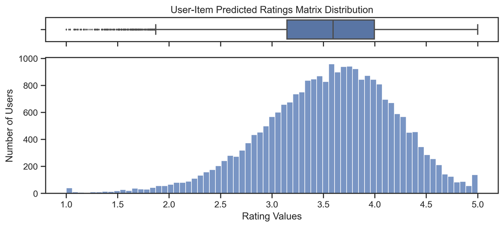

```python
with warnings.catch_warnings():
    warnings.simplefilter('ignore') # ignore warnings message

    # distribution of user ratings (after training & testing)
    figure, (ax_box, ax_hist) = plt.subplots(2, figsize = (10, 4), sharex=True, gridspec_kw={"height_ratios": (.15, .85)})

    sns.boxplot(results['predicted'], ax=ax_box, flierprops = dict(markersize=0.5, linestyle='none')
               ).set_title('User-Item Predicted Ratings Matrix Distribution')
    sns.histplot(data=results, x='predicted', ax=ax_hist)

    ax_box.set(xlabel='')

    ax_hist.set_xlabel('Rating Values')
    ax_hist.set_ylabel('Number of Users')

    plt.show()
```

```python
min(results['predicted']), np.quantile(results['predicted'], 0.25), np.median(results['predicted']), np.quantile(results['predicted'], 0.75), max(results['predicted'])
```

```
(1.0, 3.1455338585971178, 3.59417013366485, 3.9953059147416514, 5.0)
```

```python
results['predicted'].describe()
```

```
count    25000.000000
mean         3.543551
std          0.642149
min          1.000000
25%          3.145534
50%          3.594170
75%          3.995306
max          5.000000
Name: predicted, dtype: float64
```

```python
# see if distribution is normal
import statistics

print(statistics.stdev(results['predicted']))
print(statistics.median(results['predicted']))
```

```
0.6421492776823555
3.59417013366485
```

### Epoch v. RMSE

There is no explicit method within the SVD implementation for displaying the loss value for each epoch, however, we can instead repeat the experiment by recreating the same SVD algorithm with a different epoch parameter for each result. Due to cross-validation taking too long to compute, we rely on a single evaluation round for each epoch.

```python
trainset, testset = train_test_split(data, test_size=0.25)

def epoch_rmse(epoch_vals, lr=0.005, reg=0.02):
    mf_rmse = []

    for epoch in epoch_vals:
        predictions = SVD(n_epochs=epoch, lr_all=lr, reg_all=reg).fit(trainset).test(testset) # training & testing
        mf_rmse.append(accuracy.rmse(predictions, verbose=False)) # rmse
    return mf_rmse

epoch_vals = [1, 10, 20, 30, 40, 50, 60, 70, 80, 90, 100]
```

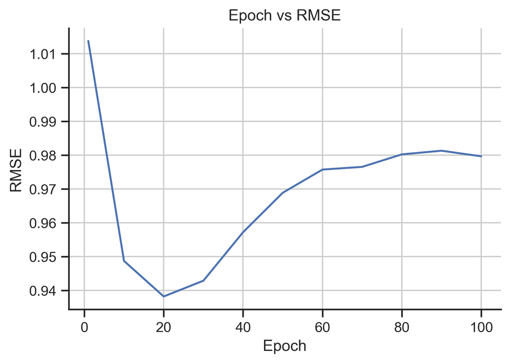

```python
sns.lineplot(data=pd.Series(epoch_rmse(epoch_vals), epoch_vals))

plt.xlabel('Epoch')
plt.ylabel('RMSE')

plt.gca().spines['top'].set_visible(False)
plt.gca().spines['right'].set_visible(False)

plt.title('Epoch vs RMSE')
plt.grid()
plt.show()
```

### Learning Rate & Regularisation

```python
svd_params_df = pd.DataFrame({
    'Low Learning Rate': epoch_rmse(epoch_vals, lr=0.00005),
    'High Learning Rate': epoch_rmse(epoch_vals, lr=0.05),
    'Low Regularisation Rate': epoch_rmse(epoch_vals, reg=0.0002),
    'High Regularisation Rate': epoch_rmse(epoch_vals, reg=2)
}, epoch_vals)
```

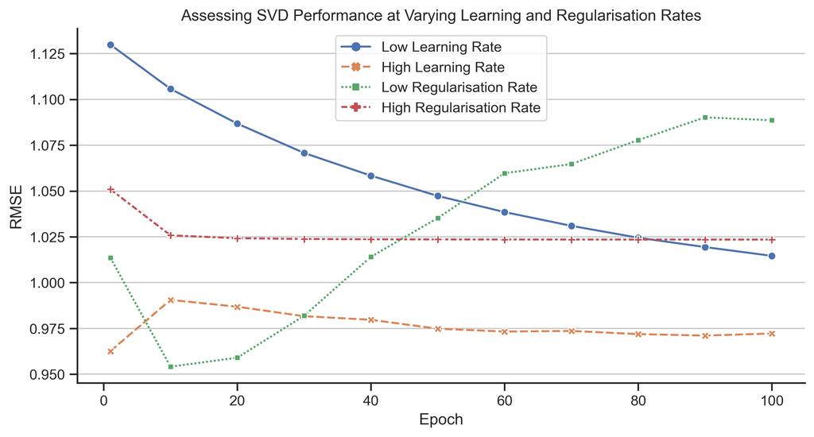

```python
fig, ax = plt.subplots(figsize=[10, 5])
ax.yaxis.grid(True)

sns.lineplot(
    data=svd_params_df,
    markers=True, dashes=True,
)
plt.xlabel('Epoch')
plt.ylabel('RMSE')

plt.gca().spines['top'].set_visible(False)
plt.gca().spines['right'].set_visible(False)

plt.title("Assessing SVD Performance at Varying Learning and Regularisation Rates")
plt.legend()
plt.show()
```

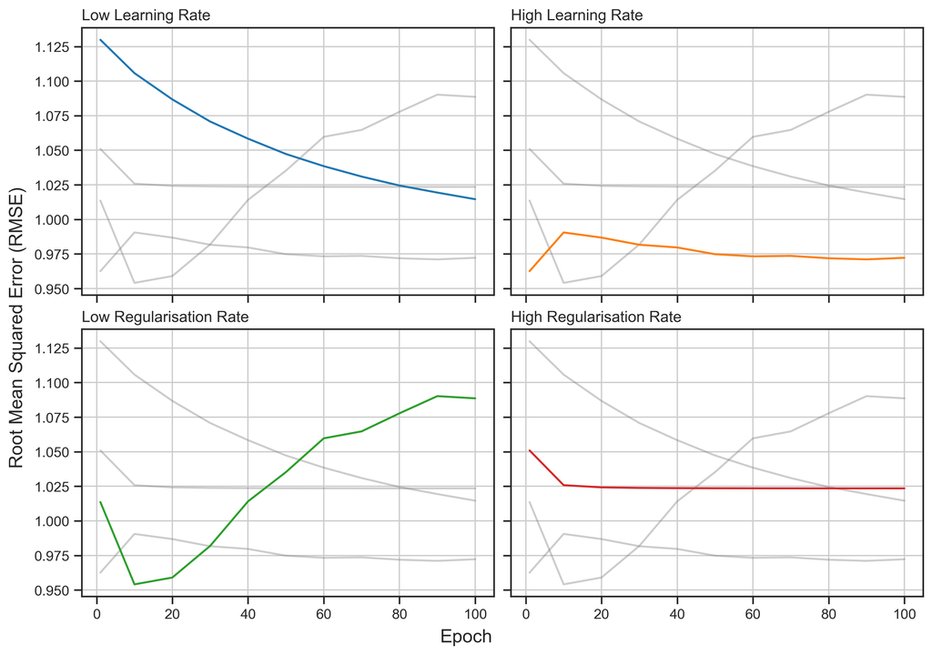

```python
num = 0
colours = ['#1f77b4', '#ff7f0e', '#2ca02c', '#d62728']

fig, axes = plt.subplots(2, 2, figsize=(10, 7), sharex=True, sharey=True, constrained_layout=True)

fig.supxlabel('Epoch')
fig.supylabel('Root Mean Squared Error (RMSE)')

ax.set(xlabel='common xlabel', ylabel='common ylabel')

for column in svd_params_df:
    num+=1

    plt.subplot(2,2, num)

    # plot other lineplots (grey)
    for v in svd_params_df:
#         sns.lineplot(data=svd_params_df[v], color='grey', alpha=0.4)
        plt.plot(svd_params_df.index, svd_params_df[v], color='grey', alpha=0.4)


    # Plot relevant lineplot
#     sns.lineplot(data=svd_params_df[column], color=colours[num-1], legend=None)
    plt.plot(svd_params_df.index, svd_params_df[column], color=colours[num-1])
    plt.grid()
    plt.title(column, loc='left')


plt.show()
```

### Grid Search

```python
param_grid = {
    'lr_all' : [0.00005, 0.0005, 0.005, 0.05, 0.5],
    'reg_all' : [0.002, 0.002, 0.02, 0.2, 1]
}

gs = GridSearchCV(SVD, param_grid)
gs.fit(data)

# best RMSE score
print(gs.best_score)
print(gs.best_params["rmse"])

# Output:
# {'rmse': 0.9361598943562596, 'mae': 0.737819524395073}
# {'lr_all': 0.005, 'reg_all': 0.02}
```

```
{'rmse': 0.9360867721841182, 'mae': 0.738399917307258}
{'lr_all': 0.005, 'reg_all': 0.02}
```

```python
print("Best RMSE: " + str(gs.best_score["rmse"]))
print("Best param_config: " + str(gs.best_params["rmse"]))
```

```
Best RMSE: 0.9360867721841182
Best param_config: {'lr_all': 0.005, 'reg_all': 0.02}
```

## Top N Recommendations

```python
trainset, testset = train_test_split(data, test_size=0.25) # train test split
algo = SVD()
predictions = algo.fit(trainset).test(testset) # training & testing

results = pd.DataFrame(predictions).drop(columns=['details'])
results.columns=['userId', 'movieId', 'actual', 'predicted']
results.head()
```

|  | userId | movieId | actual | predicted |
| --- | --- | --- | --- | --- |
| 0 | 625 | 405 | 3.0 | 2.788916 |
| 1 | 465 | 474 | 3.0 | 3.863248 |
| 2 | 303 | 21 | 2.0 | 2.593282 |
| 3 | 270 | 77 | 2.0 | 4.306704 |
| 4 | 312 | 209 | 3.0 | 3.985389 |

We are using a single user to compute a confusion matrix which is made up of values used to calculate further quantities. Instead of defining a threshold to determine what an active user would use or not use (like/not like), we instead select the 10 highest rated items from each test users to represent useful items for each active user.

```python
n_useful_items = 10 # number of useful items (arbitrary value)

# group together items corresponding to each unique userId
df_agg = results.groupby(['userId','movieId']).agg({'actual':sum})
temp = df_agg['actual'].groupby('userId', group_keys=False)

# obtain highest rated items for each user
df =  pd.DataFrame(temp.nlargest(n_useful_items))


# for each user, convert grouped items to list of item id's
arr = []

for X, new_df in df.groupby(level=0):
    temp = []
    for i in range(len(new_df.index.values)):
        temp.append(new_df.index.values[i][1])

    arr.append(temp)

# userId as dataframe index
useful_items = pd.DataFrame(df.index.get_level_values(0).unique())

useful_items['actual'] = arr
useful_items = useful_items.set_index('userId')
useful_items.head()
```

| userId | actual |
| --- | --- |
| 1 | [115, 12, 16, 170, 175, 190, 191, 198, 204, 208] |
| 10 | [12, 127, 132, 178, 183, 205, 211, 357, 435, 478] |
| 100 | [313, 258, 269, 300, 1237, 271, 342, 886, 905,... |
| 101 | [147, 24, 255, 284, 742, 1, 151, 472, 829, 840] |
| 102 | [101, 175, 186, 208, 227, 228, 307, 447, 449, ... |

*Users have varying numbers of actual ratings due to train/test splits*

```python
def get_users_predictions(user_id, model):
    """
    :type user_id: str
    :type model: int
    :rtype: List[str]
    """
    recommended_items = pd.DataFrame(model.loc[user_id])
    recommended_items.columns = ["predicted_rating"]
    recommended_items = recommended_items.sort_values('predicted_rating', ascending=False)
    return recommended_items.index.tolist()
```

```python
ratings_matrix = results.pivot(index='userId', columns='movieId', values='predicted').fillna(0)
cf_recs = [] = []

for user in useful_items.index:
    actual_length = len(useful_items['actual'].loc[useful_items.index == user][0])

    # recommendations of size equal to actual list
    cf_predictions = get_users_predictions(user, ratings_matrix)[0:actual_length]
    cf_recs.append(cf_predictions)

useful_items['recommendations'] = cf_recs
useful_items
```

| userId | actual | recommendations |
| --- | --- | --- |
| 1 | [115, 12, 16, 170, 175, 190, 191, 198, 204, 208] | [12, 199, 223, 7, 191, 175, 194, 204, 192, 258] |
| 10 | [12, 127, 132, 178, 183, 205, 211, 357, 435, 478] | [357, 50, 479, 651, 127, 12, 132, 611, 527, 205] |
| 100 | [313, 258, 269, 300, 1237, 271, 342, 886, 905,... | [313, 258, 269, 292, 300, 886, 905, 271, 1237,... |
| 101 | [147, 24, 255, 284, 742, 1, 151, 472, 829, 840] | [1, 284, 742, 255, 111, 151, 979, 24, 975, 472] |
| 102 | [101, 175, 186, 208, 227, 228, 307, 447, 449, ... | [168, 316, 313, 127, 173, 272, 181, 79, 210, 211] |
| ... | ... | ... |
| 95 | [14, 186, 207, 404, 436, 463, 50, 591, 660, 7] | [50, 79, 22, 523, 143, 215, 89, 132, 498, 357] |
| 96 | [174, 185, 64, 645, 196, 474, 87, 525] | [64, 474, 174, 525, 645, 185, 87, 196] |
| 97 | [191, 204, 482, 655, 661, 69, 168, 189, 429, 98] | [168, 661, 191, 98, 655, 429, 69, 189, 204, 496] |
| 98 | [116, 428, 629, 659, 211, 321, 322, 745, 88, 502] | [659, 428, 745, 211, 173, 116, 502, 88, 322, 629] |
| 99 | [1016, 168, 172, 181, 210, 22, 4, 475, 50, 64] | [64, 168, 963, 265, 50, 172, 181, 203, 22, 124] |

943 rows × 2 columns

```python
def compute_confusion_matrix(active_user):

    userId = str(active_user)

    a = useful_items.loc[[userId]]['actual'][userId]
    b = useful_items.loc[[userId]]['recommendations'][userId]

    # all item indexes for each user within the test set
    all_items = results.copy().groupby('userId', as_index=False)['movieId']
    all_items = all_items.agg({'all': (lambda x: list(set(x)))}).set_index("userId")

    c = all_items.loc[[userId]]['all'][userId]

    print(f'All Items: {sorted(set(c))}')
    print(f'List Length: {len(c)}', end='\n\n')

    print(f'Useful Items: {sorted(set(a))}')
    print(f'List Length: {len(a)}', end='\n\n')

    print(f'Recommended Items: {sorted(set(b))}')
    print(f'List Length: {len(b)}', end='\n\n')

    tp = len(set(a) & set(b)) # recommended + used
    fp = len(set(b) - set(a)) # recommended + not used
    fn = len(set(a) - set(b)) # not recommended + used
    tn = len(set(c) - set(b) & (set(c) - set(a))) # not recommended + not used

    print(f'TP, FP, FN, TN: {tp, fp, fn, tn}')

    return tp, fp, fn, tn
```

```python
tp, fp, fn, tn = compute_confusion_matrix(1)
```

```
All Items: ['10', '102', '103', '11', '115', '12', '123', '141', '143', '147', '16', '160', '163', '170', '175', '18', '184', '190', '191', '192', '194', '198', '199', '2', '204', '208', '212', '222', '223', '229', '230', '231', '236', '239', '24', '242', '243', '252', '254', '255', '258', '262', '2…
List Length: 64

Useful Items: ['115', '12', '16', '170', '175', '190', '191', '198', '204', '208']
List Length: 10

Recommended Items: ['12', '175', '191', '192', '194', '199', '204', '223', '258', '7']
List Length: 10

TP, FP, FN, TN: (4, 6, 6, 48)
```

The values computed can be represented within a confusion matrix which is used to illustrate classifier performance and can then be used to produce a precision-recall curve

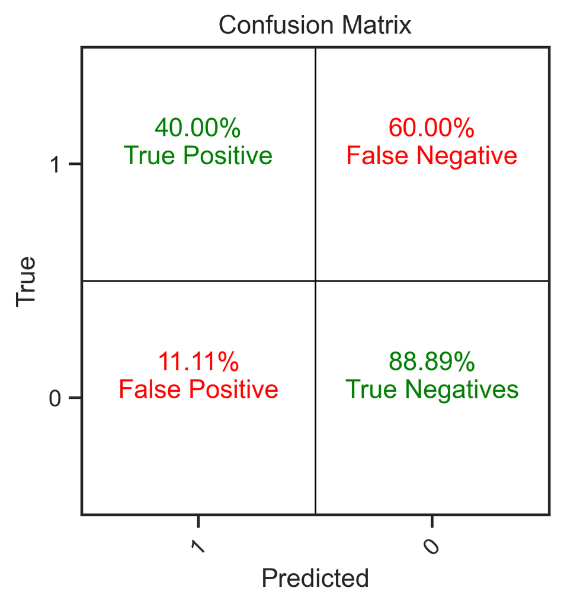

```python
def generate_confusion_matrix(tp, fp, fn, tn):
    y = []
    yhat = []

    for i in range(tp): # 1 : 1
        y.append(1)
        yhat.append(1)

    for i in range(fp): # 1 : 0
        y.append(1)
        yhat.append(0)

    for i in range(fn): # 0 : 1
        y.append(0)
        yhat.append(1)

    for i in range(tn): # 0 : 0
        y.append(0)
        yhat.append(0)

    return recmetrics.make_confusion_matrix(y, yhat)

plt.grid(False)

generate_confusion_matrix(tp, fp, fn, tn) # confusion matrix for active user 1
```

```
userId: 522

All Items: ['100', '11', '134', '173', '179', '521', '530', '654', '96']
List Length: 9

Useful Items: ['100', '11', '134', '173', '179', '521', '530', '654', '96']
List Length: 9

Recommended Items: ['100', '11', '134', '173', '179', '521', '530', '654', '96']
List Length: 9

TP, FP, FN, TN: (9, 0, 0, 0)
```

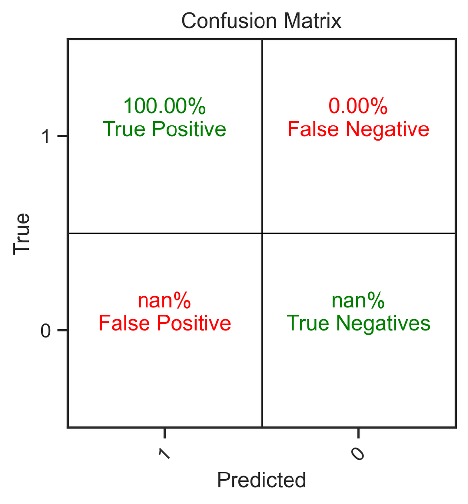

```python
# select random test user and compute confusion matrix results
random_test_user = useful_items.sample(n=1).index.values[0]

print(f'userId: {random_test_user}', end='\n\n')

tp, fp, fn, tn = compute_confusion_matrix(random_test_user)
generate_confusion_matrix(tp, fp, fn, tn)
```

### Precision@K & Recall@K

```python
# object represented as a Dataframe
data_df = pd.DataFrame(data.__dict__['raw_ratings'], columns=['userId', 'movieId', 'ratings', 'timestamp'])
data_df = data_df.drop('timestamp', axis=1) # remove timestamp column

data_df['ratings'].describe() # data statistics
```

```
count    100000.000000
mean          3.529860
std           1.125674
min           1.000000
25%           3.000000
50%           4.000000
75%           4.000000
max           5.000000
Name: ratings, dtype: float64
```

As expected, most rating values fall within the midpoint of the rating scale so we define a threshold value of 4 to ensure that rating values at or above this number are classified as useful to the active user.

```python
from collections import defaultdict

"""
predictions: predicted user ratings
k: recommendation list length
threshold: useful item rating minimum
"""
def precision_recall_at_k(predictions, k=10, threshold=4):
    """Return precision and recall at k metrics for each user"""

    # map predictions to each user.
    user_est_true = defaultdict(list) # initialise dictionary
    for uid, _, true_r, est, _ in predictions:
        user_est_true[uid].append((est, true_r)) # userId : [predicted, actual]

    precisions = dict()
    recalls = dict()
    for uid, user_ratings in user_est_true.items(): # user id : [list of (predicted, actual) ratings]

        # Sort user ratings by estimated value
        user_ratings.sort(key=lambda x: x[0], reverse=True)

        # Number of relevant items
        n_rel = sum((true_r >= threshold) for (_, true_r) in user_ratings)

        # Number of recommended items in top k
        n_rec_k = sum((est >= threshold) for (est, _) in user_ratings[:k])

        # Number of relevant and recommended items in top k
        n_rel_and_rec_k = sum(((true_r >= threshold) and (est >= threshold))
            for (est, true_r) in user_ratings[:k]
        )

        # Precision@K: Proportion of recommended items that are relevant
        precisions[uid] = n_rel_and_rec_k / n_rec_k if n_rec_k != 0 else 0

        # Recall@K: Proportion of relevant items that are recommended
        recalls[uid] = n_rel_and_rec_k / n_rel if n_rel != 0 else 0

    return precisions, recalls
```

$$ Precision = \frac{TP} {TP + FP} \quad\quad Recall = \frac{TP} {TP + FN} $$

```python
results = []

for k_val in range(1, 50, 2):
    p = []
    r = []

    for trainset, testset in KFold(n_splits=3).split(data):
        algo.fit(trainset)
        predictions = algo.test(testset)
        precisions, recalls = precision_recall_at_k(predictions, k=k_val, threshold=4)

        # Precision and recall can then be averaged over all users
        p.append(sum(prec for prec in precisions.values()) / len(precisions))
        r.append(sum(rec for rec in recalls.values()) / len(recalls))

    results.append([np.mean(p), np.mean(r)])
    print(f'[Precision, Recall] at Recommendation List Length {k_val}: {[np.mean(p), np.mean(r)]}')
```

```
[Precision, Recall] at Recommendation List Length 1: [0.7023683280311065, 0.06261218006789446]
[Precision, Recall] at Recommendation List Length 3: [0.6857546836337925, 0.14187465747214908]
[Precision, Recall] at Recommendation List Length 5: [0.6804171085189118, 0.1890223523496206]
[Precision, Recall] at Recommendation List Length 7: [0.6716347691427219, 0.21963783238091242]
[Precision, Recall] at Recommendation List Length 9: [0.6707663541438734, 0.24317974008057966]
[Precision, Recall] at Recommendation List Length 11: [0.676903586182484, 0.2589604881205372]
[Precision, Recall] at Recommendation List Length 13: [0.6709035210890989, 0.27268624310803863]
[Precision, Recall] at Recommendation List Length 15: [0.6654561798517266, 0.27854042486528036]
[Precision, Recall] at Recommendation List Length 17: [0.6666558473697765, 0.2875918109389451]
[Precision, Recall] at Recommendation List Length 19: [0.661814415090839, 0.28829189564381247]
[Precision, Recall] at Recommendation List Length 21: [0.6605996500847706, 0.2982223366605239]
[Precision, Recall] at Recommendation List Length 23: [0.6620811218092898, 0.29789689324334784]
[Precision, Recall] at Recommendation List Length 25: [0.6633009216395968, 0.30372762292220107]
[Precision, Recall] at Recommendation List Length 27: [0.6642341083117494, 0.3054201108354919]
[Precision, Recall] at Recommendation List Length 29: [0.6656196728225698, 0.3072825253561693]
[Precision, Recall] at Recommendation List Length 31: [0.662210390085035, 0.3085452876838455]
[Precision, Recall] at Recommendation List Length 33: [0.6565305828747047, 0.30968071647964496]
[Precision, Recall] at Recommendation List Length 35: [0.6612024165020377, 0.3135386394783645]
[Precision, Recall] at Recommendation List Length 37: [0.662405142498673, 0.3151673821821161]
[Precision, Recall] at Recommendation List Length 39: [0.6583753646733955, 0.3179259936159185]
[Precision, Recall] at Recommendation List Length 41: [0.6620761238791038, 0.3126583469148934]
[Precision, Recall] at Recommendation List Length 43: [0.6658257075904365, 0.31851415647979553]
[Precision, Recall] at Recommendation List Length 45: [0.6624085181217455, 0.3164028608548453]
[Precision, Recall] at Recommendation List Length 47: [0.6623286666500442, 0.31914434990423685]
[Precision, Recall] at Recommendation List Length 49: [0.6643504081879231, 0.31277300405423797]
```

```python
temp = pd.DataFrame(results, columns=['precision', 'recall'])
temp = temp.set_index(np.arange(1, 50, 2))
```

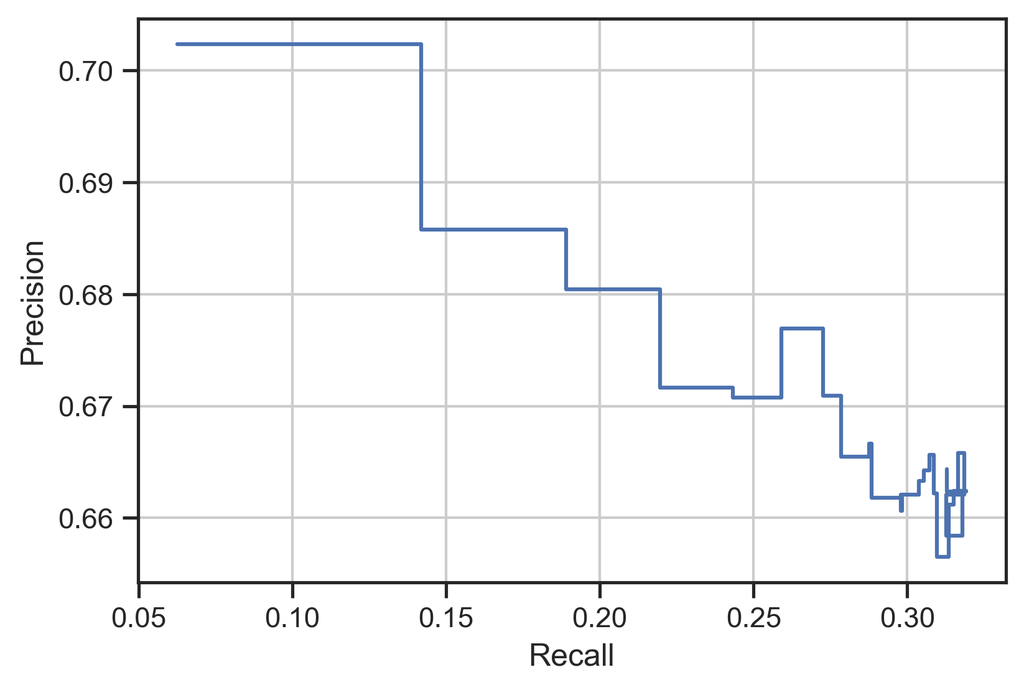

```python
# plot using sklearn library
pr_display = PrecisionRecallDisplay(precision=temp['precision'], recall=temp['recall']).plot()

plt.grid()
plt.show()
```

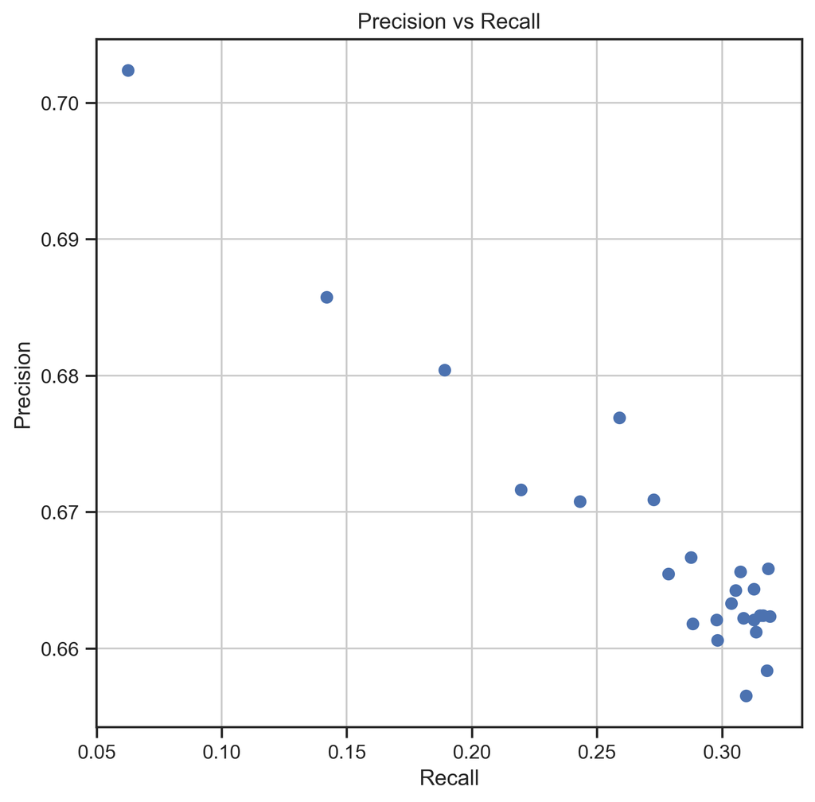

```python
# plot precision-recall scatterplot
fig, ax = plt.subplots(1, 1, figsize = (7, 7))

ax.scatter(x=temp['recall'], y=temp['precision'])
ax.set_title("Precision vs Recall")
ax.set_xlabel('Recall')
ax.set_ylabel('Precision')

plt.grid()
plt.show()
```

### F1 Measure

$$ F_1 = 2 * \frac{precision * recall} {precision + recall} $$

```python
df = temp.copy()
df.columns = (['precision', 'recall'])
df['f1_score'] = 2 * (temp['precision'] * temp['recall']) / (temp['precision'] + temp['recall'])
df
```

|  | precision | recall | f1_score |
| --- | --- | --- | --- |
| 1 | 0.702368 | 0.062612 | 0.114975 |
| 3 | 0.685755 | 0.141875 | 0.235108 |
| 5 | 0.680417 | 0.189022 | 0.295855 |
| 7 | 0.671635 | 0.219638 | 0.331024 |
| 9 | 0.670766 | 0.243180 | 0.356951 |
| 11 | 0.676904 | 0.258960 | 0.374608 |
| 13 | 0.670904 | 0.272686 | 0.387766 |
| 15 | 0.665456 | 0.278540 | 0.392706 |
| 17 | 0.666656 | 0.287592 | 0.401834 |
| 19 | 0.661814 | 0.288292 | 0.401630 |
| 21 | 0.660600 | 0.298222 | 0.410933 |
| 23 | 0.662081 | 0.297897 | 0.410909 |
| 25 | 0.663301 | 0.303728 | 0.416664 |
| 27 | 0.664234 | 0.305420 | 0.418439 |
| 29 | 0.665620 | 0.307283 | 0.420460 |
| 31 | 0.662210 | 0.308545 | 0.420954 |
| 33 | 0.656531 | 0.309681 | 0.420850 |
| 35 | 0.661202 | 0.313539 | 0.425369 |
| 37 | 0.662405 | 0.315167 | 0.427116 |
| 39 | 0.658375 | 0.317926 | 0.428791 |
| 41 | 0.662076 | 0.312658 | 0.424738 |
| 43 | 0.665826 | 0.318514 | 0.430898 |
| 45 | 0.662409 | 0.316403 | 0.428250 |
| 47 | 0.662329 | 0.319144 | 0.430737 |
| 49 | 0.664350 | 0.312773 | 0.425311 |

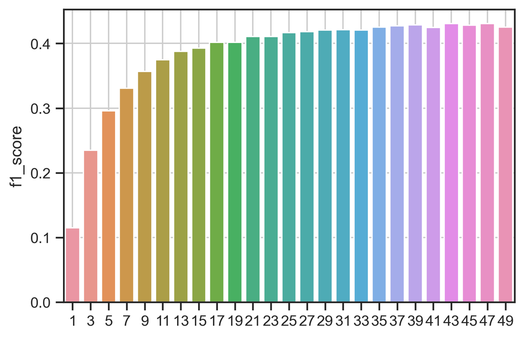

```python
sns.barplot(data=df, x=df.index, y="f1_score")
plt.grid()
plt.show()
```